# r4openEO: UC2 - Timeseries break detection

Peter Zellner, Eurac Research

22/11/2022

# Description

Process graph for getting s2 ndvi from Eurac backend, masking the clouds, and running the bfast R-UDF for detecting breaks in the time series. Additionally refining the result with the magnitude of change! Using only one UDF that can be change it’s output a ccording to the context that is passed through to it.

- extent: either test.json (100x100 px) or vaja.json
- time: 2016 to 2021

# libs

```r
library(openeo)
library(dplyr)
library(sf)
library(stars)

library(mapview)
library(mapedit)
library(ggplot2)
```

# connect to backend

```r
host = "https://openeo.eurac.edu" # "https://openeo.cloud" # "https://openeo-dev.vito.be" #
con = openeo::connect(host)
```

```
## Connected to service:  https://openeo.eurac.edu
## Please check the terms of service (terms_of_service()) and the privacy policy (privacy_policy()). By further usage of this service, you acknowledge and agree to those terms and policies.
```

```r
login()
```

```r
con$isConnected()
```

```
## [1] TRUE
```

```r
con$isLoggedIn()
```

```
## [1] FALSE
```

```r
describe_account()
```

# definitions

output file

⚠️ **Every new run on openEO needs a new name_out!**

```r
name_out = "test_magn_mask_3.tif"
file_format = "GTiff" # "GTiff" # "netCDF"
pth_out = "~/git_projects/r4openeo-usecases/uc2-ts-breakdetection/openeo_eurac/results"
pth_out = file.path(pth_out, name_out)
pth_out
```

```
## [1] "~/git_projects/r4openeo-usecases/uc2-ts-breakdetection/openeo_eurac/results/test_magn_mask_3.tif"
```

path to spatial extent

```r
pth_ext = "~/git_projects/r4openeo-usecases/uc2-ts-breakdetection/00_extent/test.json"
```

path to udf

```r
pth_udf =  "https://raw.githubusercontent.com/Open-EO/r4openeo-usecases/main/uc2-ts-breakdetection/00_udfs/bfast_udf_handle_null.R"
```

# parameters

```r
collection = "S2_L2A_T32TPS" #"S2_L2A_ALPS"
spatial_extent = jsonlite::read_json(pth_ext)
time_range = list("2016-01-01", "2021-01-01")
bands = c("B04_10m", "B08_10m", "SCL_20m")
bands_cloud = "SCL_20m"
```

# define process graph

```r
p = openeo::processes()

data = p$load_collection(id = collection,
                         spatial_extent = list(west = spatial_extent$spatial_extent$west,
                                               east = spatial_extent$spatial_extent$east,
                                               south = spatial_extent$spatial_extent$south,
                                               north = spatial_extent$spatial_extent$north),
                         temporal_extent = time_range, bands = bands)

data_clouds = p$filter_bands(data = data, bands = bands_cloud)

fun_cloud_mask = function(data, context) {
  scl = data
  res = scl == 3 | scl == 8 | scl == 9
  return(res)
  }

cloud_mask = p$apply(data = data_clouds, process = fun_cloud_mask)

mask_clouds = p$mask(data = data, mask = cloud_mask)

calc_ndvi = p$reduce_dimension(data = mask_clouds,
                               dimension = "bands",
                               reducer = function(data, context) {
                                 red = data[1]
                                 nir = data[2]
                                 (nir-red)/(nir+red)})

reduce_udf = p$reduce_dimension(data = calc_ndvi,
                                dimension = "DATE", # at Eurac it's called DATE, at VITO "time" or "t"
                                reducer = function(data, context){
                                  p$run_udf(data = data,
                                            context = list(start_monitor = 2018),
                                            udf = pth_udf,
                                            runtime = "R")})

reduce_udf_magn = p$reduce_dimension(data = calc_ndvi,
                                dimension = "DATE",
                                reducer = function(data, context){
                                  p$run_udf(data = data,
                                            context = list(start_monitor = 2018,
                                                           val = "magnitude"),
                                            udf = pth_udf,
                                            runtime = "R")})

fun_magn_mask = function(data, context) {
  magn = data
  res = magn > -0.2
  return(res)
  }

magn_mask = p$apply(data = reduce_udf_magn, process = fun_magn_mask)

mask_magn = p$mask(data = reduce_udf, mask = magn_mask)

result = p$save_result(data = mask_magn, format=file_format) # "GTiff" #"netCDF"
```

# look at the pg

```r
pg_json = as(result, "Process")
pg_json
```

# create job

create job

```r
job = create_job(graph = result,
                 title = name_out,
                 description = name_out,
                 format = file_format)
start_job(job = job$id)
```

status job

```r
status(job) # 3.5 min for test.json extent with 2 udfs
```

download

```r
result_obj = list_results(job = job$id)
dwnld = download_results(job = job$id, folder = pth_out)
```

# Check Results

First look

```r
file.size(dwnld[[2]])/1000000 # mb
```

```
## [1] 0.088837
```

```r
brks = read_stars(dwnld[[2]])
brks[[1]][brks[[1]]<2018] = NA
mapview::mapview(brks)
```

[interactive chart not shown]

# Get a NDVI time series from one of the breakpoints

Select a point from the result

```r
pnt = mapedit::drawFeatures(map = mapview(brks))
# pnt
```

⚠️ **This section shows how to reuse parts of a process graph**

Reuse the process graph up to ndvi calculation

```r
pg_json_ndvi = as(calc_ndvi, "Process")
pg_json_ndvi
```

Update the extent

```r
# updating the node data, will also update the downstream node calc_ndvi...
data$parameters$spatial_extent
```

```
## $west
## [1] 11.52191
##
## $east
## [1] 11.53504
##
## $south
## [1] 46.4369
##
## $north
## [1] 46.4459
```

```r
data$parameters$spatial_extent = pnt # with an sf object
data$parameters$spatial_extent
```

```
##     xmin     ymin     xmax     ymax
## 11.52876 46.43926 11.52876 46.43926
```

and the format for saving

```r
format_ts = "netCDF"
result_ndvi = p$save_result(data = calc_ndvi, format = format_ts)
```

Look at the process graph to validate the changes have been made

```r
pg_json_ndvi = as(result_ndvi, "Process")
pg_json_ndvi
```

Calculate the NDVI synchronously

```r
pth_out_ndvi = paste0(tools::file_path_sans_ext(pth_out), ".nc")
a = Sys.time()
compute_result(result_ndvi, output_file = pth_out_ndvi)
b = Sys.time()-a
b

# job = create_job(graph = result,
#                  title = name_out,
#                  description = name_out,
#                  format = file_format)
# start_job(job = job$id)
```

Load the NDVI

```r
#ndvi_px = read_ncdf(pth_out_ndvi)
ndvi_px = read_stars(pth_out_ndvi)
ndvi_px_df = data.frame(value = ndvi_px %>% pull() %>% c() %>% as.vector(),
                        dates = as.Date(st_get_dimension_values(ndvi_px, "time")))
```

Plot the NDVI - red line = event date, blue line = r4openeo detection

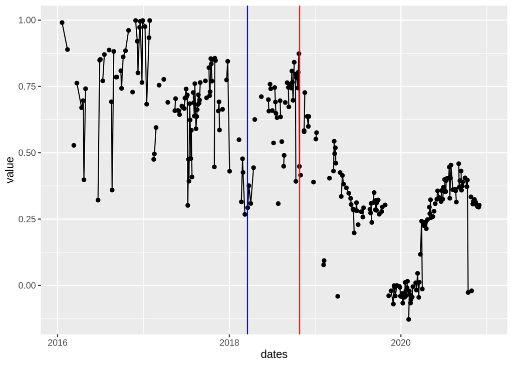

```r
event_date = "2018-10-27"
break_date = brks[st_transform(x = pnt, crs = st_crs(brks))] %>% pull() %>% c()

plot_px = ggplot(ndvi_px_df, aes(x = dates, y = value)) +
  geom_line() +
  geom_point() +
  geom_vline(xintercept = as.Date(event_date), col = "red") +
  geom_vline(xintercept = as.Date(lubridate::date_decimal(break_date)), col = "blue")

plot_px
```

```r
# plot_px_plotly = plotly::ggplotly(plot_px)
# plot_px_plotly
```

# Compare to ECO4Alps

## Breaks

Load ECO4Alps breaks

```r
pth_eco = "/mnt/CEPH_PROJECTS/ECO4Alps/Forest_Disturbances_SLX/03_results_slx/bfast_brks_refined_with_magnitude/brks_2016_2020_start_2018_level_0.001_magn_-0.2.tif"
brks_eco = read_stars(pth_eco)
brks_eco = st_warp(src = brks_eco, dest = brks)
brks_eco = brks_eco[st_bbox(brks)]
brks_eco[[1]][brks_eco[[1]]==0] = NA
```

Map the breaks

```r
mapview(brks) + mapview(brks_eco) + mapview(pnt)
```

[interactive chart not shown]

Prepare breaks for plotting

```r
brks_eco_v = as.vector(brks_eco[[1]])
brks_eco_v[brks_eco_v < 2018] = NA
brks_eco_v = data.frame(source = "eco", brks = brks_eco_v)
brks_v = as.vector(brks[[1]])
brks_v = data.frame(source = "r4o", brks = brks_v)
brks_v[brks_v < 2018] = NA
brks_all_v = rbind(brks_eco_v, brks_v)
```

Plot break timings - red line = event date of the vaja storm, blue line = r4openEO break, green line = eco4alps break

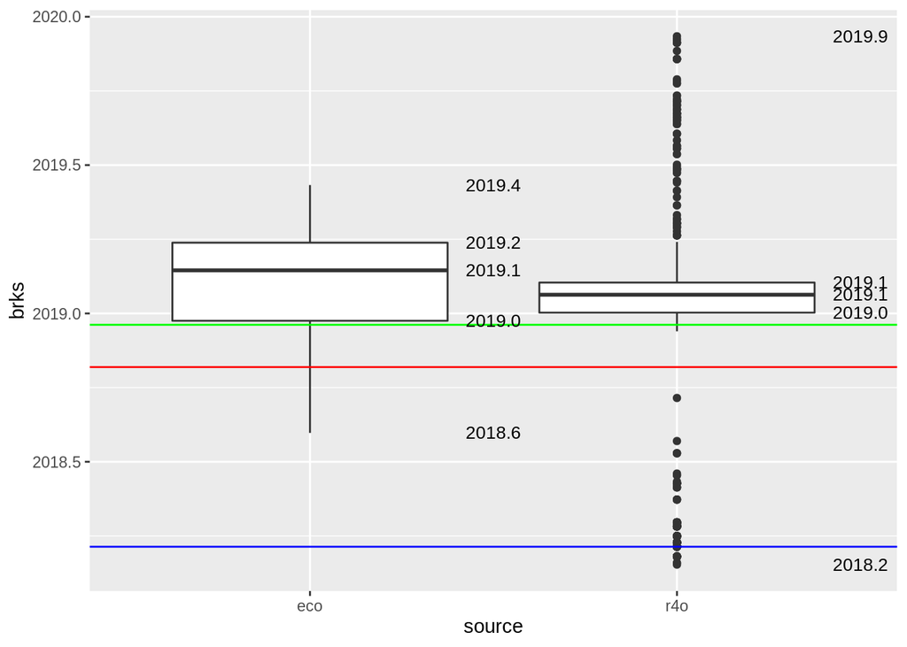

```r
break_date_eco = brks_eco[st_transform(pnt, crs = st_crs(brks_eco))] %>% pull() %>% c()

brks_boxplot = ggplot(brks_all_v, aes(x = source, y = brks, group = source)) +
  geom_boxplot() +
  geom_hline(yintercept = lubridate::decimal_date(as.Date(event_date)), col = "red") +
  geom_hline(yintercept = break_date, col = "blue") +
  geom_hline(yintercept = break_date_eco, col = "green") +
  stat_summary(geom="text", fun=quantile,
               aes(label=sprintf("%1.1f", ..y..)),
               position=position_nudge(x=0.5), size=3.5)

brks_boxplot
```

And as histogram - red line = event date of the vaja storm, blue line = r4openEO break, green line = eco4alps break

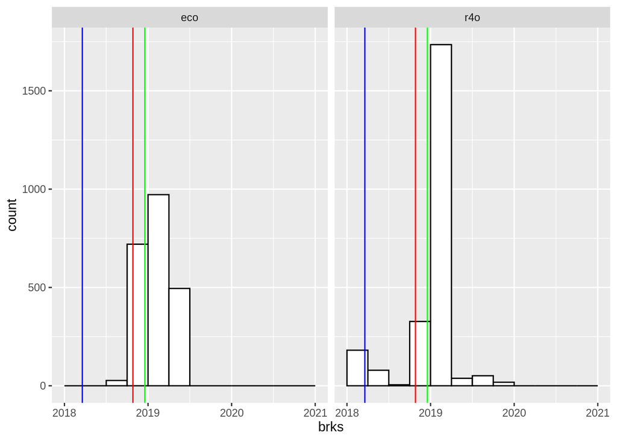

```r
yrs = c(2018:2021)
plt_hist_lags = ggplot(brks_all_v, aes(x=brks)) +
  geom_histogram(color="black", fill="white",
                 breaks=seq(from = min(yrs), to = max(yrs), by= 0.25)) +
  geom_vline(xintercept = lubridate::decimal_date(as.Date(event_date)), color = "red") +
  geom_vline(xintercept = break_date, color = "blue") +
  geom_vline(xintercept = break_date_eco, color = "green") +
  facet_wrap(~ source)

plt_hist_lags
```

## NDVI time series

Load NDVI time series ECO4Alps

```r
pth_ndvi_eco = "/mnt/CEPH_PROJECTS/ECO4Alps/Forest_Disturbances_SLX/WeSendit-20220829120870/20220510-fd/20220510-fd/indices/"
lst_ndvi_eco = list.files(path = pth_ndvi_eco, pattern = ".tif$", full.names = TRUE)
dts_ndvi_eco = gsub(pattern =".*_([0-9][0-9][0-9][0-9]-[0-9][0-9]-[0-9][0-9])\\.tif$" ,
                    replacement = "\\1",
                    x = lst_ndvi_eco)
dts_ndvi_eco = as.Date(dts_ndvi_eco)
ndvi_eco = read_stars(.x = lst_ndvi_eco, along = "time", proxy = TRUE)
ndvi_eco = ndvi_eco[st_transform(pnt, crs = st_crs(ndvi_eco))]
ndvi_eco_ts = st_as_stars(ndvi_eco)
ndvi_eco_df = data.frame(value = ndvi_eco_ts %>% pull() %>% c() %>% as.vector(),
                         dates = dts_ndvi_eco)
```

Combine the NDVI time series

```r
ndvi_eco_df$src = "eco"
ndvi_px_df$src = "r4o"
ndvi_all_df = rbind(ndvi_px_df, ndvi_eco_df)
```

Plot the two NDVI time series - red line = event date of the vaja storm, blue line = r4openEO break, green line = eco4alps break

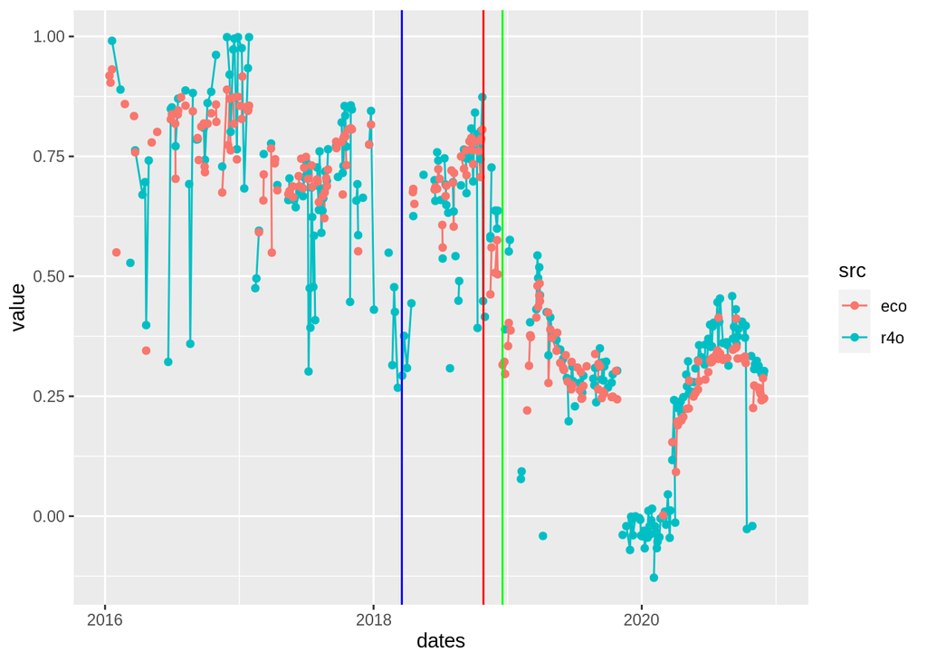

```r
plot_px2 = ggplot(ndvi_all_df, aes(x = dates, y = value, col = src)) +
  geom_line() +
  geom_point() +
  geom_vline(xintercept = as.Date(event_date), col = "red") +
  geom_vline(xintercept = as.Date(lubridate::date_decimal(break_date)), col = "blue") +
  geom_vline(xintercept = as.Date(lubridate::date_decimal(break_date_eco)), col = "green")

plot_px2
```